# sklearn.cluster.MiniBatchKMeans

**class*sklearn.cluster.MiniBatchKMeans(*n_clusters=8*, *, *init='k-means++'*, *max_iter=100*, *batch_size=1024*, *verbose=0*, *compute_labels=True*, *random_state=None*, *tol=0.0*, *max_no_improvement=10*, *init_size=None*, *n_init=3*, *reassignment_ratio=0.01*)[[source]](https://github.com/scikit-learn/scikit-learn/blob/f3f51f9b6/sklearn/cluster/_kmeans.py#L1589)**

Mini-Batch K-Means clustering.

Read more in the User Guide.

**Parameters:**

**n_clusters**int, default=8**

The number of clusters to form as well as the number of centroids to generate.

**init**{‘k-means++’, ‘random’}, callable or array-like of shape (n_clusters, n_features), default=’k-means++’**

Method for initialization:

‘k-means++’ : selects initial cluster centroids using sampling based on an empirical probability distribution of the points’ contribution to the overall inertia. This technique speeds up convergence, and is theoretically proven to be $\mathcal{O}(\log k)$-optimal. See the description of `n_init` for more details.

‘random’: choose `n_clusters` observations (rows) at random from data for the initial centroids.

If an array is passed, it should be of shape (n_clusters, n_features) and gives the initial centers.

If a callable is passed, it should take arguments X, n_clusters and a random state and return an initialization.

**max_iter**int, default=100**

Maximum number of iterations over the complete dataset before stopping independently of any early stopping criterion heuristics.

**batch_size**int, default=1024**

Size of the mini batches. For faster computations, you can set the `batch_size` greater than 256 * number of cores to enable parallelism on all cores.

Changed in version 1.0: `batch_size` default changed from 100 to 1024.

**verbose**int, default=0**

Verbosity mode.

**compute_labels**bool, default=True**

Compute label assignment and inertia for the complete dataset once the minibatch optimization has converged in fit.

**random_state**int, RandomState instance or None, default=None**

Determines random number generation for centroid initialization and random reassignment. Use an int to make the randomness deterministic. See [Glossary](https://scikit-learn.org/1.1/glossary.html#term-random_state).

**tol**float, default=0.0**

Control early stopping based on the relative center changes as measured by a smoothed, variance-normalized of the mean center squared position changes. This early stopping heuristics is closer to the one used for the batch variant of the algorithms but induces a slight computational and memory overhead over the inertia heuristic.

To disable convergence detection based on normalized center change, set tol to 0.0 (default).

**max_no_improvement**int, default=10**

Control early stopping based on the consecutive number of mini batches that does not yield an improvement on the smoothed inertia.

To disable convergence detection based on inertia, set max_no_improvement to None.

**init_size**int, default=None**

Number of samples to randomly sample for speeding up the initialization (sometimes at the expense of accuracy): the only algorithm is initialized by running a batch KMeans on a random subset of the data. This needs to be larger than n_clusters.

If `None`, the heuristic is `init_size = 3 * batch_size` if `3 * batch_size < n_clusters`, else `init_size = 3 * n_clusters`.

**n_init**int, default=3**

Number of random initializations that are tried. In contrast to KMeans, the algorithm is only run once, using the best of the `n_init` initializations as measured by inertia. Several runs are recommended for sparse high-dimensional problems (see Clustering sparse data with k-means).

**reassignment_ratio**float, default=0.01**

Control the fraction of the maximum number of counts for a center to be reassigned. A higher value means that low count centers are more easily reassigned, which means that the model will take longer to converge, but should converge in a better clustering. However, too high a value may cause convergence issues, especially with a small batch size.

**Attributes:**

**cluster_centers_**ndarray of shape (n_clusters, n_features)**

Coordinates of cluster centers.

**labels_**ndarray of shape (n_samples,)**

Labels of each point (if compute_labels is set to True).

**inertia_**float**

The value of the inertia criterion associated with the chosen partition if compute_labels is set to True. If compute_labels is set to False, it’s an approximation of the inertia based on an exponentially weighted average of the batch inertiae. The inertia is defined as the sum of square distances of samples to their cluster center, weighted by the sample weights if provided.

**n_iter_**int**

Number of iterations over the full dataset.

**n_steps_**int**

Number of minibatches processed.

New in version 1.0.

**n_features_in_**int**

Number of features seen during fit.

New in version 0.24.

**feature_names_in_**ndarray of shape (`n_features_in_`,)**

Names of features seen during fit. Defined only when `X` has feature names that are all strings.

New in version 1.0.

See also

**`KMeans`**

The classic implementation of the clustering method based on the Lloyd’s algorithm. It consumes the whole set of input data at each iteration.

#### Notes

See https://www.eecs.tufts.edu/~dsculley/papers/fastkmeans.pdf

When there are too few points in the dataset, some centers may be duplicated, which means that a proper clustering in terms of the number of requesting clusters and the number of returned clusters will not always match. One solution is to set `reassignment_ratio=0`, which prevents reassignments of clusters that are too small.

#### Examples

```
>>> from sklearn.cluster import MiniBatchKMeans
>>> import numpy as np
>>> X = np.array([[1, 2], [1, 4], [1, 0],
...               [4, 2], [4, 0], [4, 4],
...               [4, 5], [0, 1], [2, 2],
...               [3, 2], [5, 5], [1, -1]])
>>> # manually fit on batches
>>> kmeans = MiniBatchKMeans(n_clusters=2,
...                          random_state=0,
...                          batch_size=6)
>>> kmeans = kmeans.partial_fit(X[0:6,:])
>>> kmeans = kmeans.partial_fit(X[6:12,:])
>>> kmeans.cluster_centers_
array([[2. , 1. ],
       [3.5, 4.5]])
>>> kmeans.predict([[0, 0], [4, 4]])
array([0, 1], dtype=int32)
>>> # fit on the whole data
>>> kmeans = MiniBatchKMeans(n_clusters=2,
...                          random_state=0,
...                          batch_size=6,
...                          max_iter=10).fit(X)
>>> kmeans.cluster_centers_
array([[1.19..., 1.22...],
       [4.03..., 2.46...]])
>>> kmeans.predict([[0, 0], [4, 4]])
array([0, 1], dtype=int32)
```

#### Methods

| `fit`(X[, y, sample_weight]) | Compute the centroids on X by chunking it into mini-batches. |
| --- | --- |
| `fit_predict`(X[, y, sample_weight]) | Compute cluster centers and predict cluster index for each sample. |
| `fit_transform`(X[, y, sample_weight]) | Compute clustering and transform X to cluster-distance space. |
| `get_feature_names_out`([input_features]) | Get output feature names for transformation. |
| `get_params`([deep]) | Get parameters for this estimator. |
| `partial_fit`(X[, y, sample_weight]) | Update k means estimate on a single mini-batch X. |
| `predict`(X[, sample_weight]) | Predict the closest cluster each sample in X belongs to. |
| `score`(X[, y, sample_weight]) | Opposite of the value of X on the K-means objective. |
| `set_params`(**params) | Set the parameters of this estimator. |
| `transform`(X) | Transform X to a cluster-distance space. |

**fit(*X*, *y=None*, *sample_weight=None*)[[source]](https://github.com/scikit-learn/scikit-learn/blob/f3f51f9b6/sklearn/cluster/_kmeans.py#L1938)**

Compute the centroids on X by chunking it into mini-batches.

**Parameters:**

**X**{array-like, sparse matrix} of shape (n_samples, n_features)**

Training instances to cluster. It must be noted that the data will be converted to C ordering, which will cause a memory copy if the given data is not C-contiguous. If a sparse matrix is passed, a copy will be made if it’s not in CSR format.

**y**Ignored**

Not used, present here for API consistency by convention.

**sample_weight**array-like of shape (n_samples,), default=None**

The weights for each observation in X. If None, all observations are assigned equal weight.

New in version 0.20.

**Returns:**

**self**object**

Fitted estimator.

**fit_predict(*X*, *y=None*, *sample_weight=None*)[[source]](https://github.com/scikit-learn/scikit-learn/blob/f3f51f9b6/sklearn/cluster/_kmeans.py#L973)**

Compute cluster centers and predict cluster index for each sample.

Convenience method; equivalent to calling fit(X) followed by predict(X).

**Parameters:**

**X**{array-like, sparse matrix} of shape (n_samples, n_features)**

New data to transform.

**y**Ignored**

Not used, present here for API consistency by convention.

**sample_weight**array-like of shape (n_samples,), default=None**

The weights for each observation in X. If None, all observations are assigned equal weight.

**Returns:**

**labels**ndarray of shape (n_samples,)**

Index of the cluster each sample belongs to.

**fit_transform(*X*, *y=None*, *sample_weight=None*)[[source]](https://github.com/scikit-learn/scikit-learn/blob/f3f51f9b6/sklearn/cluster/_kmeans.py#L1035)**

Compute clustering and transform X to cluster-distance space.

Equivalent to fit(X).transform(X), but more efficiently implemented.

**Parameters:**

**X**{array-like, sparse matrix} of shape (n_samples, n_features)**

New data to transform.

**y**Ignored**

Not used, present here for API consistency by convention.

**sample_weight**array-like of shape (n_samples,), default=None**

The weights for each observation in X. If None, all observations are assigned equal weight.

**Returns:**

**X_new**ndarray of shape (n_samples, n_clusters)**

X transformed in the new space.

**get_feature_names_out(*input_features=None*)[[source]](https://github.com/scikit-learn/scikit-learn/blob/f3f51f9b6/sklearn/base.py#L909)**

Get output feature names for transformation.

**Parameters:**

**input_features**array-like of str or None, default=None**

Only used to validate feature names with the names seen in `fit`.

**Returns:**

**feature_names_out**ndarray of str objects**

Transformed feature names.

**get_params(*deep=True*)[[source]](https://github.com/scikit-learn/scikit-learn/blob/f3f51f9b6/sklearn/base.py#L194)**

Get parameters for this estimator.

**Parameters:**

**deep**bool, default=True**

If True, will return the parameters for this estimator and contained subobjects that are estimators.

**Returns:**

**params**dict**

Parameter names mapped to their values.

**partial_fit(*X*, *y=None*, *sample_weight=None*)[[source]](https://github.com/scikit-learn/scikit-learn/blob/f3f51f9b6/sklearn/cluster/_kmeans.py#L2095)**

Update k means estimate on a single mini-batch X.

**Parameters:**

**X**{array-like, sparse matrix} of shape (n_samples, n_features)**

Training instances to cluster. It must be noted that the data will be converted to C ordering, which will cause a memory copy if the given data is not C-contiguous. If a sparse matrix is passed, a copy will be made if it’s not in CSR format.

**y**Ignored**

Not used, present here for API consistency by convention.

**sample_weight**array-like of shape (n_samples,), default=None**

The weights for each observation in X. If None, all observations are assigned equal weight.

**Returns:**

**self**object**

Return updated estimator.

**predict(*X*, *sample_weight=None*)[[source]](https://github.com/scikit-learn/scikit-learn/blob/f3f51f9b6/sklearn/cluster/_kmeans.py#L998)**

Predict the closest cluster each sample in X belongs to.

In the vector quantization literature, `cluster_centers_` is called the code book and each value returned by `predict` is the index of the closest code in the code book.

**Parameters:**

**X**{array-like, sparse matrix} of shape (n_samples, n_features)**

New data to predict.

**sample_weight**array-like of shape (n_samples,), default=None**

The weights for each observation in X. If None, all observations are assigned equal weight.

**Returns:**

**labels**ndarray of shape (n_samples,)**

Index of the cluster each sample belongs to.

**score(*X*, *y=None*, *sample_weight=None*)[[source]](https://github.com/scikit-learn/scikit-learn/blob/f3f51f9b6/sklearn/cluster/_kmeans.py#L1085)**

Opposite of the value of X on the K-means objective.

**Parameters:**

**X**{array-like, sparse matrix} of shape (n_samples, n_features)**

New data.

**y**Ignored**

Not used, present here for API consistency by convention.

**sample_weight**array-like of shape (n_samples,), default=None**

The weights for each observation in X. If None, all observations are assigned equal weight.

**Returns:**

**score**float**

Opposite of the value of X on the K-means objective.

**set_params(**params)[[source]](https://github.com/scikit-learn/scikit-learn/blob/f3f51f9b6/sklearn/base.py#L218)**

Set the parameters of this estimator.

The method works on simple estimators as well as on nested objects (such as `Pipeline`). The latter have parameters of the form `<component>__<parameter>` so that it’s possible to update each component of a nested object.

**Parameters:**

**paramsdict**

Estimator parameters.

**Returns:**

**self**estimator instance**

Estimator instance.

**transform(*X*)[[source]](https://github.com/scikit-learn/scikit-learn/blob/f3f51f9b6/sklearn/cluster/_kmeans.py#L1059)**

Transform X to a cluster-distance space.

In the new space, each dimension is the distance to the cluster centers. Note that even if X is sparse, the array returned by `transform` will typically be dense.

**Parameters:**

**X**{array-like, sparse matrix} of shape (n_samples, n_features)**

New data to transform.

**Returns:**

**X_new**ndarray of shape (n_samples, n_clusters)**

X transformed in the new space.

## Examples using `sklearn.cluster.MiniBatchKMeans`

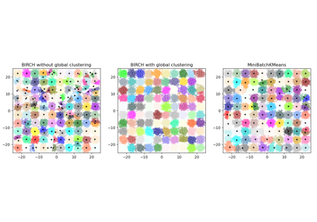

Compare BIRCH and MiniBatchKMeans

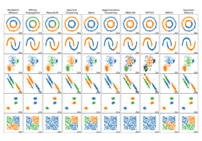

Comparing different clustering algorithms on toy datasets

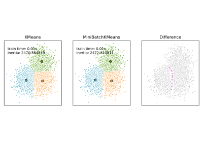

Comparison of the K-Means and MiniBatchKMeans clustering algorithms

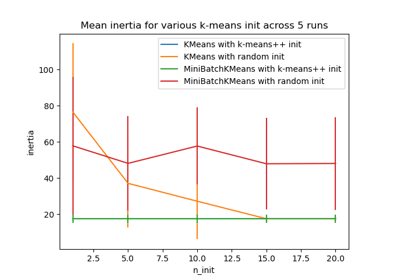

Empirical evaluation of the impact of k-means initialization

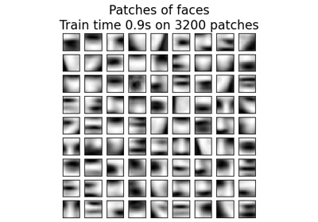

Online learning of a dictionary of parts of faces

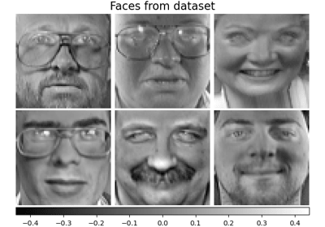

Faces dataset decompositions

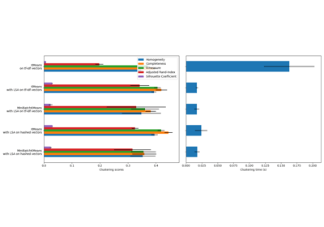

Clustering text documents using k-means